# Analyses Of LNG Plant Constructions Engineering Deliverables Progress, Planned & Forecast

Ashifuddin Mandal & Maryam Mehdipour

2023-07-24

# Important Terms

**Data Analysis** is the process of systematically applying statistical and/or logical techniques to describe and illustrate, condense and recap, and evaluate data.

**Project Management** The use of procedures, techniques, abilities, knowledge, and experience to accomplish certain project goals in accordance with established standards is known as project management.

**Deliverable** Deliverable are basically the products of project activities, which are produced by projects. The size and number of project deliverable might vary depending on the project. During the project planning phase, the project management team and stakeholders come to an arrangement about the specifications of deliverable.

**Weight factor** A weight factor is a numerical value assigned to an element or variable to indicate its relative importance or significance within a larger system or calculation.

# Engineering deliverable progress report

- Communication
- Transparency
- Accountability
- Decision Making
- Performance Evaluation

# Problem & Solution

Within the dynamic organizational structure of the EPC construction contractors operating on LNG plants. When there are more than 1000 deliverable documents to manage, things get extremely complicated. In order to maintain the project’s baseline schedule, it is essential to keep track of any delays and visualize the progress that has been made.

This procedure will define a method for calculating the progress of the engineering work into the various levels in accordance with the scope of the work and the supply. In order to calculate the overall engineering progress.

# Data set

The data set for this project has been taken from TGE Gas Engineering GmbH. We can have a look into the variables of the considered data set below.

```r
library(knitr)
library(kableExtra)
library(readxl)
library(dplyr)
dataSet <- read_excel("C:/Users/MandalA/Downloads/project/dataSet.xlsx")
kable(dataSet)
```

[output not shown]

[output cut: 534 more lines]

# Structure

The structure of this project is divided into four parts, where firstly we arrange the number of monthly progress we need. We have variable of dates for the for Plan , Forecast & Actual. Secondly, we need to get a curve of plan dates according to the months. Thirdly, we need to get a curve of Forecast dates according to the months and finally we need to get a curve of Actual progress. At the end we will marge all the data to analyze the progress and delays.

# Slide with R Output

```r
# Importing the required packages
library(readxl)
library(dplyr)
```

```r
dummydf <- data.frame (date_month  = c("2022-01",
                                  "2022-02",
                                  "2022-03",
                                  "2022-04",
                                  "2022-05",
                                  "2022-06",
                                  "2022-07",
                                  "2022-08",
                                  "2022-09",
                                  "2022-10",
                                  "2022-11",
                                  "2022-12",
                                  "2023-01",
                                  "2023-02",
                                  "2023-03",
                                  "2023-04",
                                  "2023-05",
                                  "2023-06",
                                  "2023-07",
                                  "2023-08",
                                  "2023-09",
                                  "2023-10",
                                  "2023-11",
                                  "2023-12",
                                  "2024-01",
                                  "2024-02",
                                  "2024-03",
                                  "2024-04"
))
```

# reading the excel data file

```r
dataSet <- read_excel("C:/Users/MandalA/Downloads/project/dataSet.xlsx")
print(dataSet)
```

```
## # A tibble: 564 × 21
##    `Document ID`            Title      `Current Revision` Current Client Revis…¹
##    <chr>                    <chr>      <chr>              <chr>
##  1 C5663/CS30/CAL/4500/3101 Static Ca… <NA>               <NA>
##  2 C5663/CS30/CAL/4500/3201 Static Ca… B                  EO2
##  3 C5663/CS30/CAL/4500/3301 Static Ca… <NA>               <NA>
##  4 C5663/CS30/CAL/4500/3401 Static Ca… 1                  EA1
##  5 C5663/CS30/CAL/4500/3501 Static Ca… 2                  EF1
##  6 C5663/CS30/CAL/4500/3601 Static ca… 2                  EF1
##  7 C5663/CS30/CAL/4500/3701 Static Ca… <NA>               <NA>
##  8 C5663/CS30/CAL/4500/3702 Static Ca… <NA>               <NA>
##  9 C5663/CS30/DWG/4500/3101 Steel Str… <NA>               <NA>
## 10 C5663/CS30/DWG/4500/3102 Steel Str… <NA>               <NA>
## # ℹ 554 more rows
## # ℹ abbreviated name: ¹`Current Client Revision`
## # ℹ 17 more variables: `Client Document ID` <chr>, `Document Purpose` <chr>,
## #   `Client Action` <chr>, `Client Review Status` <chr>, Discipline <chr>,
## #   `Man Hours` <dbl>, Responsible <chr>, Keywords <lgl>, `Client WBS` <chr>,
## #   `Document Need Translation` <lgl>, `Work Pack ID` <lgl>,
## #   `IFR Planned` <dttm>, `IFR Forecast` <dttm>, `IFR Actual` <dttm>, …
```

# calculating weights

```r
dataSet$weight <- round((dataSet$`Man Hours`/sum(dataSet$`Man Hours`))*100, digits = 4)

dataSet$weightIFR <- round((dataSet$`Man Hours`/sum(dataSet$`Man Hours`))*70, digits = 4)

dataSet$weightIFU <- round((dataSet$`Man Hours`/sum(dataSet$`Man Hours`))*30, digits = 4)
```

### calculating weight per discipline

```r
dataSet <- dataSet %>%
  group_by(Discipline) %>%
  mutate(WeightPerDiscipline = sum(`Man Hours`))

dataSet$WeightPerDiscipline <- round((dataSet$`Man Hours`/ dataSet$WeightPerDiscipline)*100, digits = 3)
```

# For planned

```r
#Aggregating IFR based on month
dfp_IFR <- aggregate(weightIFR ~ format(as.Date(dataSet$`IFR Planned`) , "%Y-%m") , dataSet , sum )
colnames(dfp_IFR)[1] ="date_month"
```

```r
#Aggregating IFU
dfp_IFU <- aggregate(weightIFU ~ format(as.Date(dataSet$`IFU Planned`) , "%Y-%m") , dataSet , sum )
colnames(dfp_IFU)[1] ="date_month"

dfp_IFR_IFU <- merge(x=dfp_IFR,y=dfp_IFU, by = c("date_month"),all = TRUE)
dfp_IFR_IFU[is.na(dfp_IFR_IFU)] <- 0

dfp_IFR_IFU$totalPlaned <- dfp_IFR_IFU$weightIFR+dfp_IFR_IFU$weightIFU

dfp_IFR_IFU_planned <- merge(x=dummydf,y=dfp_IFR_IFU, by = c("date_month"),all = TRUE)

dfp_IFR_IFU_planned[is.na(dfp_IFR_IFU_planned)] <- 0

dfp_IFR_IFU_planned <- select(dfp_IFR_IFU_planned ,date_month, totalPlaned)

dfp_IFR_IFU_planned <- dfp_IFR_IFU_planned %>%
                      mutate(totalRunningPLan = cumsum(totalPlaned))

dfp_IFR_IFU_planned <- select(dfp_IFR_IFU_planned ,date_month, totalRunningPLan)
```

# For Forecast

```r
#Aggregating IFR based on month
dff_IFR <- aggregate(weightIFR ~ format(as.Date(dataSet$`IFR Forecast`) , "%Y-%m") , dataSet , sum )
colnames(dff_IFR)[1] ="date_month"
```

```r
#Aggregating IFU
dff_IFU <- aggregate(weightIFU ~ format(as.Date(dataSet$`IFU Forecast`) , "%Y-%m") , dataSet , sum )
colnames(dff_IFU)[1] ="date_month"

dff_IFR_IFU <- merge(x=dff_IFR,y=dff_IFU, by = c("date_month"),all = TRUE)
dff_IFR_IFU[is.na(dff_IFR_IFU)] <- 0

dff_IFR_IFU$totalForecast <- dff_IFR_IFU$weightIFR+dff_IFR_IFU$weightIFU

dff_IFR_IFU_Forecast <- merge(x=dummydf,y=dff_IFR_IFU, by = c("date_month"),all = TRUE)

dff_IFR_IFU_Forecast[is.na(dff_IFR_IFU_Forecast)] <- 0

dff_IFR_IFU_Forecast <- select(dff_IFR_IFU_Forecast ,date_month, totalForecast)

dff_IFR_IFU_Forecast <- dff_IFR_IFU_Forecast %>%
  mutate(totalRunningForecast = cumsum(totalForecast))

dff_IFR_IFU_Forecast <- select(dff_IFR_IFU_Forecast ,date_month, totalRunningForecast)
```

# For Actual

```r
#Aggregating IFR based on month
dfa_IFR <- aggregate(weightIFR ~ format(as.Date(dataSet$`IFR Actual`) , "%Y-%m") , dataSet , sum )
colnames(dfa_IFR)[1] ="date_month"
```

```r
#Aggregating IFU
dfa_IFU <- aggregate(weightIFU ~ format(as.Date(dataSet$`IFU Actual`) , "%Y-%m") , dataSet , sum )
colnames(dfa_IFU)[1] ="date_month"

dfa_IFR_IFU <- merge(x=dfa_IFR,y=dfa_IFU, by = c("date_month"),all = TRUE)
dfa_IFR_IFU[is.na(dfa_IFR_IFU)] <- 0

dfa_IFR_IFU$totalActual <- dfa_IFR_IFU$weightIFR+dfa_IFR_IFU$weightIFU

dfa_IFR_IFU_Actual <- merge(x=dummydf,y=dfa_IFR_IFU, by = c("date_month"),all = TRUE)

dfa_IFR_IFU_Actual[is.na(dfa_IFR_IFU_Actual)] <- 0

dfa_IFR_IFU_Actual <- select(dfa_IFR_IFU_Actual ,date_month, totalActual)

dfa_IFR_IFU_Actual <- dfa_IFR_IFU_Actual %>%
  mutate(totalRunningActual = cumsum(totalActual))

dfa_IFR_IFU_Actual <- select(dfa_IFR_IFU_Actual ,date_month, totalRunningActual)
```

# Merging three final dataframes

```r
df_final <- merge(x=dfp_IFR_IFU_planned,y=dff_IFR_IFU_Forecast, by = c("date_month"),all = TRUE)
df_final <- merge(x=df_final,y=dfa_IFR_IFU_Actual, by = c("date_month"),all = TRUE)
```

# Plot

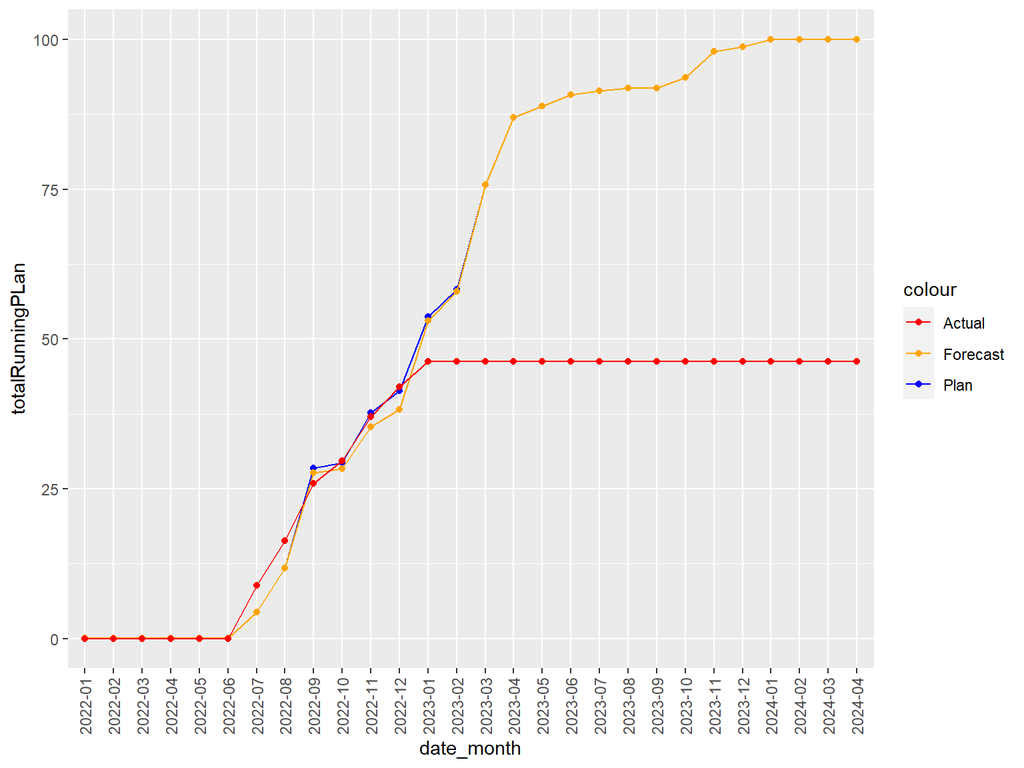

```r
library(ggplot2)


ggplot(data = df_final) +
  geom_line(mapping = aes(x = date_month, y = totalRunningPLan, group = 1, color = "Plan")) +
  geom_point(mapping = aes(x = date_month, y = totalRunningPLan, group = 1, color = "Plan")) +
  geom_line(mapping = aes(x = date_month, y = totalRunningForecast, group = 1, color = "Forecast")) +
  geom_point(mapping = aes(x = date_month, y = totalRunningForecast, group = 1, color = "Forecast")) +
  geom_line(mapping = aes(x = date_month, y = totalRunningActual, group = 1, color = "Actual")) +
  geom_point(mapping = aes(x = date_month, y = totalRunningActual, group = 1, color = "Actual")) +
  scale_x_discrete(guide = guide_axis(check.overlap = TRUE)) +
  scale_color_manual(values = c("Plan" = "blue", "Forecast" = "orange", "Actual" = "red")) +
  theme(axis.text.x = element_text(angle = 90, vjust = 0.5))
```